# GAN

Shan-Hung Wu & DataLab  
Fall 2019

In this lab, we are going to introduce an unsupervised learning model: [Generative adversarial network(GAN)](https://papers.nips.cc/paper/5423-generative-adversarial-nets.pdf)  
The architecture of GAN look like following.

[figure not shown]

GAN has two main components in the model, generator and discriminator. Discriminator tries to discriminate real data from generated data and generator tries to generate real-like data to fool discriminator. The training process alternates between optimizing discriminator and optimizing generator. As long as discriminator was smart enough, it can lead generator to go toward the manifold of real datas.

[figure not shown]

```python
%env CUDA_VISIBLE_DEVICES=0
%matplotlib inline
import numpy as np
import matplotlib.pyplot as plt
import tensorflow as tf
import tensorflow.keras as keras
import imageio
import moviepy.editor as mpy

BATCH_SIZE = 5000
SAMPLE_COL = 16
SAMPLE_ROW = 16
SAMPLE_NUM = SAMPLE_COL * SAMPLE_ROW
IMG_H = 28
IMG_W = 28
IMG_C = 1
IMG_SHAPE = (IMG_H, IMG_W, IMG_C)
Z_DIM = 128
BUF = 65536
DC_LR = 2.5e-04
DC_EPOCH = 256
W_LR = 2.0e-04
W_EPOCH = 256
BZ = (BATCH_SIZE, Z_DIM)
WClipLo = -0.01
WClipHi = 0.01
```

```
env: CUDA_VISIBLE_DEVICES=0
```

```python
gpus = tf.config.experimental.list_physical_devices('GPU')
tf.config.experimental.set_memory_growth(gpus[0], True)
tf.config.experimental.set_virtual_device_configuration(gpus[0], [tf.config.experimental.VirtualDeviceConfiguration(memory_limit = 0x2400)])
```

## DCGAN

DCGAN is short for Deep Convolutional Generative Adversarial Networks. It is a paper that doing well on image task, its architecture increase training stability and quality of generated sample. In this lab, we modified the code of [DCGAN](https://arxiv.org/pdf/1511.06434.pdf). We will demo the training of DCGAN on MNIST dataset.

[figure not shown]

Some suggestions in DCGAN(referenced from paper):

- Replace any pooling layers with strided convolutions (discriminator) and fractional-strided convolutions (generator).
  - Each convolutional layer halved the feature maps resolution. (Not hard requirement.)
- Use batch normalization in both the generator and the discriminator.
  - The batch normalization here is the simplest one just normalizing the feature activations.
  - Do not use batch normalization in the last few layers in generator, since it may make it difficult for generator to fit the variance of real data. For example, if the mean of data is not zero, and we use batchnorm and tanh in the last layer of G, then it will never match the true data distribution.
- Use ReLU activation in generator for all layers except for the output, which uses tanh or sigmoid.
  - Depends on the range of real data.
- Use LeakyReLU activation in the discriminator for all layers.
  - LeakyReLu is recommened by AllConvNet approach for faster training.
- In the following code, we
  1. design the model architecture following suggestion proposed in dcgan.
  2. initialize DCGAN and train on the MNIST dataset.

```python
(train_images, _), (test_images, _) = tf.keras.datasets.mnist.load_data()

iTrain = train_images.reshape(-1, 28, 28, 1).astype(np.float32)

# Normalizing the images to the range of [0., 1.]
iTrain = iTrain / 255.0

dsTrain = tf.data.Dataset.from_tensor_slices(iTrain).shuffle(BUF).batch(BATCH_SIZE, True)

# Utility function
def utPuzzle(imgs, row, col, path = None):
    h, w, c = imgs[0].shape
    out = np.zeros((h * row, w * col, c), np.uint8)
    for n, img in enumerate(imgs):
        j, i = divmod(n, col)
        out[j * h : (j + 1) * h, i * w : (i + 1) * w, :] = img
    if path is not None : imageio.imwrite(path, out)
    return out

def utMakeGif(imgs, fname, duration):
    n = float(len(imgs)) / duration
    clip = mpy.VideoClip(lambda t : imgs[int(n * t)], duration = duration)
    clip.write_gif(fname, fps = n)
```

```python
def GAN(sp, zd):
    # Shape
    xh, xw, xc = sp
    zh = xh // 4
    zw = xw // 4

    # Model
    return keras.Sequential([
        keras.layers.Dense(units  =  1024, input_shape = (zd,)),
        keras.layers.BatchNormalization(),
        keras.layers.ReLU(),
        keras.layers.Dense(units  =  zh * zw << 8),
        keras.layers.BatchNormalization(),
        keras.layers.ReLU(),
        keras.layers.Reshape(target_shape = (zh, zw, 256)),
        keras.layers.Conv2DTranspose(
            filters = 32,
            kernel_size = 5,
            strides = 2,
            padding = "SAME"
        ),
        keras.layers.BatchNormalization(),
        keras.layers.ReLU(),
        keras.layers.Conv2DTranspose(
            filters = xc,
            kernel_size = 5,
            strides = 2,
            padding = "SAME",
            activation = keras.activations.sigmoid
        ),
    ]), keras.Sequential([
        keras.layers.Conv2D(
            filters = 32,
            kernel_size = 5,
            strides = (2, 2),
            padding = "SAME",
            input_shape = sp,
        ),
        keras.layers.LeakyReLU(),
        #keras.layers.Dropout(0.3),
        keras.layers.Conv2D(
            filters = 128,
            kernel_size = 5,
            strides = (2, 2),
            padding = "SAME"
        ),
        keras.layers.BatchNormalization(),
        keras.layers.LeakyReLU(),
        #keras.layers.Dropout(0.3),
        keras.layers.Flatten(),
        keras.layers.Dense(units  =  1024),
        keras.layers.BatchNormalization(),
        keras.layers.LeakyReLU(),
        keras.layers.Dense(units  =  1),
    ])

s = tf.random.normal([SAMPLE_NUM, Z_DIM])
```

```python
DCG, DCD = GAN(IMG_SHAPE, Z_DIM)
opg = keras.optimizers.Adam(DC_LR)
opd = keras.optimizers.Adam(DC_LR)

cross_entropy = keras.losses.BinaryCrossentropy(from_logits = True)

def DCGLoss(c0):
    return cross_entropy(tf.ones_like(c0), c0)

def DCDLoss(c0, c1):
    l1 = cross_entropy(tf.ones_like(c1), c1)
    l0 = cross_entropy(tf.zeros_like(c0), c0)
    return l1 + l0

@tf.function
def DCDTrain(c1):
    z = tf.random.normal(BZ)

    with tf.GradientTape() as tp:
        c0 = DCG(z, training = True)

        z1 = DCD(c1, training = True)
        z0 = DCD(c0, training = True)

        lg = DCGLoss(z0)
        ld = DCDLoss(z0, z1)

    gd = tp.gradient(ld, DCD.trainable_variables)

    opd.apply_gradients(zip(gd, DCD.trainable_variables))

    return lg, ld

@tf.function
def DCGTrain(c1):
    z = tf.random.normal(BZ)

    with tf.GradientTape() as tp:
        c0 = DCG(z, training = True)


        z1 = DCD(c1, training = True)
        z0 = DCD(c0, training = True)

        lg = DCGLoss(z0)
        ld = DCDLoss(z0, z1)

    gg = tp.gradient(lg, DCG.trainable_variables)

    opg.apply_gradients(zip(gg, DCG.trainable_variables))

    return lg, ld


DCTrain = (
    DCDTrain,
    DCDTrain,
    DCDTrain,
    DCDTrain,
    DCDTrain,
    DCGTrain
)

DCCritic = len(DCTrain)
```

Let's plot the generated images right after the initialization. It's good to check if there are any unexpacted artifacts in it. For case of DCGAN, we should see checkboard effect in our generated samples if we use fully convolutional layers. As mentioned in this [blog post](http://distill.pub/2016/deconv-checkerboard/), this will introduce some checkboard effect. If the training is succeed, then this effect can be largely reduced. The blog post used upsampling to replace strided deconvolution in generator. This can cancell off the checkboard effect but have more blury result.

```
Generator Initial Output :
```

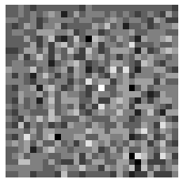

```
Discriminator Initial Output : 4.343332E-02
```

```python
print("Generator Initial Output :")
c0 = DCG(tf.random.normal((1, Z_DIM)), training = False)
plt.imshow((c0[0, :, :, 0] * 255.0).numpy().astype(np.uint8), cmap = "gray")
plt.axis("off")
plt.show()
print("Discriminator Initial Output : %E" % DCD(c0).numpy())
```

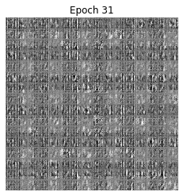

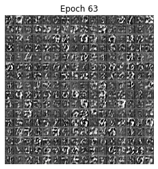

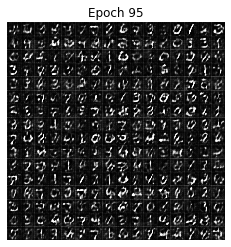

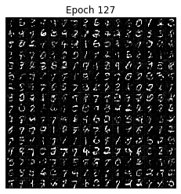

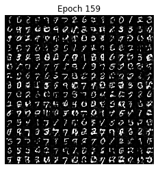

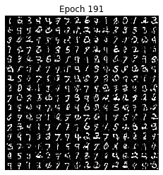

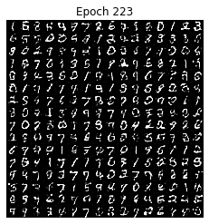

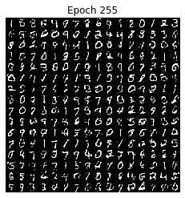

```python
dclg = [None] * DC_EPOCH
dcld = [None] * DC_EPOCH
dcsp = [None] * DC_EPOCH
rsTrain = float(BATCH_SIZE) / float(len(iTrain))
ctr = 0
for ep in range(DC_EPOCH):
    lgt = 0.0
    ldt = 0.0
    for c1 in dsTrain:
        lg, ld = DCTrain[ctr](c1)
        ctr += 1
        lgt += lg.numpy()
        ldt += ld.numpy()
        if ctr == DCCritic : ctr = 0
    dclg[ep] = lgt * rsTrain
    dcld[ep] = ldt * rsTrain

    out = DCG(s, training = False)
    img = utPuzzle(
        (out * 255.0).numpy().astype(np.uint8),
        SAMPLE_COL,
        SAMPLE_ROW,
        "imgs/dc_%04d.png" % ep
    )
    dcsp[ep] = img
    if ep & 0x1F == 0x1F:
        plt.imshow(img[..., 0], cmap = "gray")
        plt.axis("off")
        plt.title("Epoch %d" % ep)
        plt.show()
```

```python
utMakeGif(np.array(dcsp), "imgs/dcgan.gif", duration = 2)
```

```
MoviePy - Building file imgs/dcgan.gif with imageio.
```

[figure not shown]

We plot the training loss of discriminator and generator. We can see that we can't tell the model is converged or not from the training loss. Both curves oscillate at certain levels and it's independent with the quality of the generated images. So in practice, we plot the generated samples to monitor the training process. And due to this inconvenience, there are some works proposed in 2017 tried to solved it.

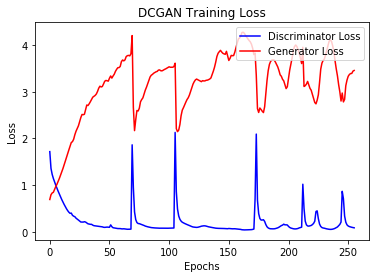

```python
plt.plot(range(DC_EPOCH), dcld, color = "blue", label = "Discriminator Loss")
plt.plot(range(DC_EPOCH), dclg, color = "red", label = "Generator Loss")
plt.legend(loc = "upper right")
plt.xlabel("Epochs")
plt.ylabel("Loss")
plt.title("DCGAN Training Loss")
plt.show()
```

# Wasserstein GAN

There are some theoretical deficiencies in vanilla GAN. [Wasserstein GAN (WGAN)](https://arxiv.org/pdf/1701.07875.pdf) was proposed to solve these problems. Apart from the original paper, [this](https://www.cph-ai-lab.com/wasserstein-gan-wgan) and [this](https://www.alexirpan.com/2017/02/22/wasserstein-gan.html) may help you understand the motivation of WGAN. We'll skip the theory in this tutorial and jump directly to the implementation. From the engineering perspective, the following are modification compared with origin GAN.

- Do not apply sigmoid function to the last layer for the critic.
- Do not apply logarithmic function to the generator loss and critic loss.
- Training critic multiple iterations per generator iteration.
- Using RMSProp as the optimizer, instead of momentum related optimizer like Adam. [Here](http://ruder.io/optimizing-gradient-descent/index.html#rmsprop) is a blog overview of gradient descent optimization algorithm.
- Applying weight clipping in the critic network.

Details of the algorithm are shown below.

[figure not shown]

```python
WG, WD = GAN(IMG_SHAPE, Z_DIM)
opg = keras.optimizers.RMSprop(W_LR)
opd = keras.optimizers.RMSprop(W_LR)

@tf.function
def WGTrain(c1):
    z = tf.random.normal(BZ)

    with tf.GradientTape() as tpg:
        c0 = WG(z, training = True)

        z1 = WD(c1, training = True)
        z0 = WD(c0, training = True)

        ld = tf.reduce_mean(z0)
        lg = - ld
        ld = ld - tf.reduce_mean(z1)

    gg = tpg.gradient(lg, WG.trainable_variables)

    opg.apply_gradients(zip(gg, WG.trainable_variables))

    return lg, ld

@tf.function
def WDTrain(c1):
    z = tf.random.normal(BZ)

    with tf.GradientTape() as tpd:
        c0 = WG(z, training = True)

        z1 = WD(c1, training = True)
        z0 = WD(c0, training = True)

        ld = tf.reduce_mean(z0)
        lg = - ld
        ld = ld - tf.reduce_mean(z1)

    gd = tpd.gradient(ld, WD.trainable_variables)

    opd.apply_gradients(zip(gd, WD.trainable_variables))
    for v in WD.trainable_variables : v.assign(tf.clip_by_value(v, WClipLo, WClipHi))

    return lg, ld

WTrain = (
    WDTrain,
    WDTrain,
    WDTrain,
    WDTrain,
    WDTrain,
    WGTrain
)

WCritic = len(WTrain)
```

Then we train the WGAN and visualize the training as before.

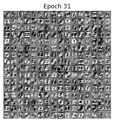

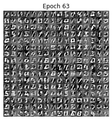

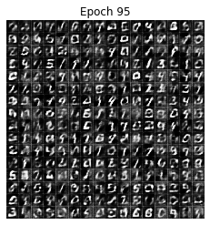

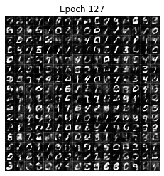

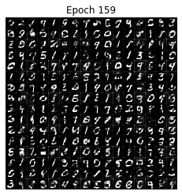

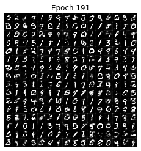

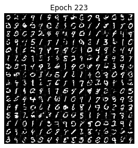

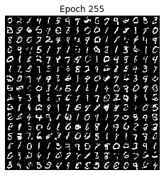

```python
wlg = [None] * W_EPOCH
wld = [None] * W_EPOCH
wsp = [None] * W_EPOCH
rsTrain = float(BATCH_SIZE) / float(len(iTrain))
ctr = 0
for ep in range(W_EPOCH):
    lgt = 0.0
    ldt = 0.0
    for c1 in dsTrain:
        lg, ld = WTrain[ctr](c1)
        ctr += 1
        lgt += lg.numpy()
        ldt += ld.numpy()
        if ctr == WCritic : ctr = 0
    wlg[ep] = lgt * rsTrain
    wld[ep] = ldt * rsTrain

    out = WG(s, training = False)
    img = utPuzzle(
        (out * 255.0).numpy().astype(np.uint8),
        SAMPLE_COL,
        SAMPLE_ROW,
        "imgs/w_%04d.png" % ep
    )
    wsp[ep] = img
    if ep & 0x1F == 0x1F:

        plt.imshow(img[..., 0], cmap = "gray")
        plt.axis("off")
        plt.title("Epoch %d" % ep)
        plt.show()
```

```python
utMakeGif(np.array(wsp), "imgs/wgan.gif", duration = 2)
```

```
MoviePy - Building file imgs/wgan.gif with imageio.
```

[figure not shown]

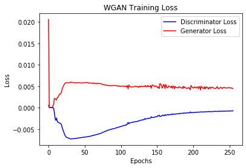

```python
plt.plot(range(W_EPOCH), wld, color = "blue", label = "Discriminator Loss")
plt.plot(range(W_EPOCH), wlg, color = "red", label = "Generator Loss")
plt.legend(loc = "upper right")
plt.xlabel("Epochs")
plt.ylabel("Loss")
plt.title("WGAN Training Loss")
plt.show()
```

# Improved WGAN

Although Wasserstein GAN (WGAN) made progress toward stable training of GANs, still fail to converge in some settings. In this lab, you are required to implement [Improved Wasserstein GANs](https://arxiv.org/pdf/1704.00028.pdf), which is a milestone for GANs research.

Details of the algorithm are shown below.

[figure not shown]

# Assignment

1. Implement the **[Improved WGAN](https://arxiv.org/pdf/1704.00028.pdf)**.
2. Train the Improved WGAN on **[CelebA](https://drive.google.com/drive/folders/0B7EVK8r0v71pbWNEUjJKdDQ3dGc)** dataset. Build dataset that **read** and **resize** images to **64 x 64** for training.
3. Show a **gif of generated samples (at least 8 x 8)** to demonstrate the training process and show the **best generated sample(s)**. Please make sure that these images can be correctly loaded.
4. Draw the **loss curve of discriminator and generator** during training process into **one image**.
5. Write a **brief report** about what you have done.

## Notification

- Upload the notebook named **Lab14_2_{strudent_id}.ipynb** to demonstrate your codes and report on google drive, then submit the **link** to iLMS.
- The deadline will be **2019/12/12 23:59**.